# ESTIMACIÓN Y CAUSALIDAD DE LOS EFECTOS DINÁMICOS DE LAS VARIABLES FISCALES SOBRE EL PIB EN COLOMBIA: UNA APLICACIÓN VAR

Carlos Arturo Cáceres Ojeda (caceresojeda@gmail.com)

## RESUMEN

En el presente artículo se realiza un ejercicio de replica de un modelo de Vectores Autorregresivos (VAR) para el caso colombiano, teniendo como base el trabajo de Blanchard y Perotti (2002) *An Empirical Characterization of the Dynamic Effects of Changes in Goverment Spending and Taxes on Output*. De esta forma, se muestra el proceso de estimación de un modelo VAR para las variables *Gasto del Gobierno*, *Impuestos* y *PIB*, con el objetivo de caracterizar los choques (*innovaciones*) de las variables fiscales sobre el producto, para esto se calculan tanto las funciones de *impulso respuesta* como la *descomposición de varianza* y se comprueba el sentido de la *causalidad en sentido de Granger* en el sistema de ecuaciones compuesto por el modelo VAR.

## 1. SELECCIÓN DE LAS LIBRERÍAS QUE SE UTILIZARÁN

```r
library(tseries)
library(vars)
library(lmtest)
library(sandwich)
library(forecast)
library(urca)
library(uroot)
library(fUnitRoots)
```

```r
library(readr)
library(readxl)
library(ggplot2)
```

## 2. IMPORTACIÓN DE LAS SERIES DE TIEMPO: GASTO DEL GOBIERTNO, IMPUESTOS Y PIB

De acuerdo con Blanchard y Perotti (2002), para hacer la estimación del modelo VAR se tiene en cuenta las siguientes variables:

- **Gasto del Gobierno:** a precios corrientes desestacionalizados obtenidos del DANE con frecuencia trimestral desde el 2005-I hasta el 2018-IV
- **PIB:** a precios corrientes desestacionalizados obtenidos del DANE con frecuencia trimestral desde el 2005-I hasta el 2018-IV
- **Impuestos:** corresponde con los recaudos impositivos obtenidos de la DIAN, con frecuencia mensual, para obtener la cifra trimestral se acumularon de a tres meses y se igualó en los mismos tiempos que las series del PIB y el Gasto del Gobierno.

```r
setwd("~/Hoja de Vida/Proyectos/VAR_Fiscal")
DATOS_R <- read_excel("DATOS_R.xlsx")
View(DATOS_R)
```

## 3. TRANSFORMACIÓN DE LAS SERIES

Siguendo a Blanchard y Perotti (2002), se requiere que las variables para el modelo estén en términos reales, per-cápita y en logaritmos; sin embargo, también se tendrán todas las series desestacionalizadas para simplificar el modelo. De esta manera, debido a que la variable de los recaudos de impuestos tiene una naturaleza estacional, se procede a desestacionalizarla por método de descomposición de series de tiempo; mientras que para el Gasto del Gobierno y el PIB se utilizan las variables desestacionalizadas provistas por el DANE. Adicionalmente, las series anteriores fueron transformadas en términos reales al deflactarlas con respecto al IPC de base 2008, y convertidas en per-cápita al dividirlas por la Población Económicamente Activa. Finalmente, cada serie se transforma en logaritmos.

**Nota:** por simplicidad se seguirán nombrando las series como *Impuestos (T)*, *Gasto del Gobierno (G)* y *PIB (Y)*, sin embargo, éstas corresponderán a las series de desestacionalizadas, en términos reales, per-cápita y en logaritmos.

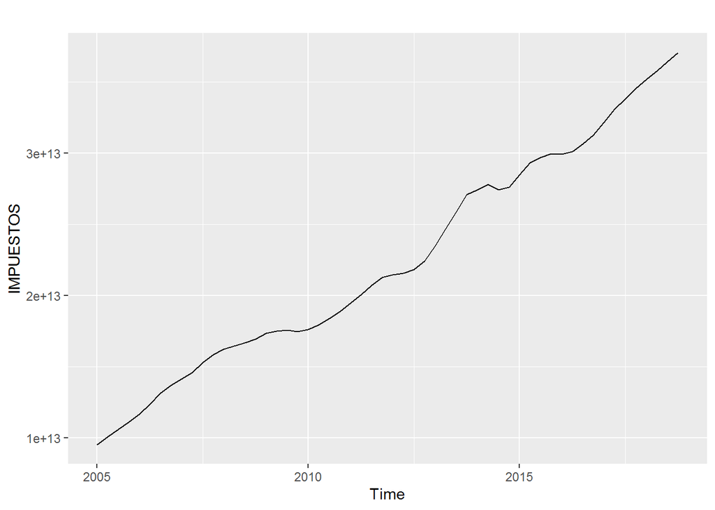

```r
fred <- ts(DATOS_R, start=c(2005,1),end=c(2018,4),frequency=4)

# Desestacionalización de los Recaudos de Impuestos
DES_TAX <- stl(fred[,"RECAUDOS"], s.window="periodic", robust=TRUE)
IMPUESTOS <- DES_TAX$time.series[,"trend"]
autoplot(IMPUESTOS)
```

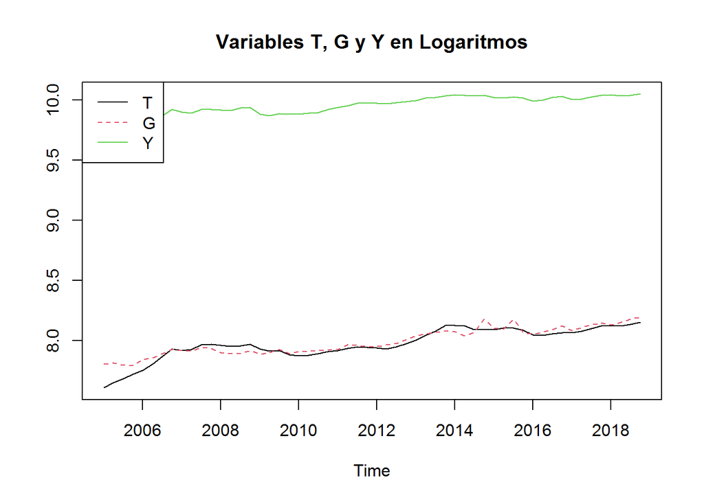

```r
# Variables de Interés
DATOS_2 <- cbind(fred[,"IPC"],fred[,"PEA"],IMPUESTOS,fred[,"GASTO_G"],fred[,"PIB"])

# Transformación de variables en términos reales, per-cápita y en logaritmos
T <- log((DATOS_2[,3]/DATOS_2[,1])/DATOS_2[,2])
G <- log((DATOS_2[,4]/DATOS_2[,1])/DATOS_2[,2])
Y <- log((DATOS_2[,5]/DATOS_2[,1])/DATOS_2[,2])
DATOS_VAR <- cbind(T,G,Y)

# Variables T, G y Y en logaritmos
ts.plot(DATOS_VAR[,"T"],DATOS_VAR[,"G"],DATOS_VAR[,"Y"], type="l", lty=c(1,2), col=c(1,2,3), main = "Variables T, G y Y en Logaritmos")
legend("topleft", border=NULL, legend=c("T","G","Y"), lty=c(1,2), col=c(1,2,3))
```

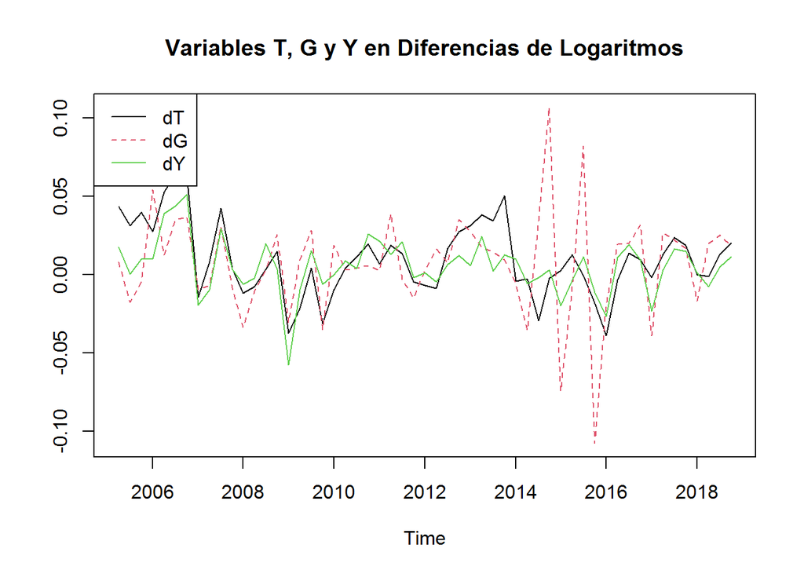

```r
# Variables T, G y Y en diferencia de logaritmos
ts.plot(diff(DATOS_VAR[,"T"]),diff(DATOS_VAR[,"G"]),diff(DATOS_VAR[,"Y"]), type="l", lty=c(1,2), col=c(1,2,3), main = "Variables T, G y Y en Diferencias de Logaritmos")
legend("topleft", border=NULL, legend=c("dT","dG","dY"), lty=c(1,2), col=c(1,2,3))
```

## 4. PRUEBAS DE ESTACIONARIEDAD - Pruebas Dickey-Fuller (ADF)

La Prueba de Dickey Fuller busca determinar la existencia o no de raíces unitarias en cada una de las series de tiempo. Si alguna serie tiene raíz unitaria, implica que no es estacionaria, por lo que sería necesario aplicarle una diferenciación ordinaria para así lograr que sea estacionaria.

Para un nivel $\alpha*100\%$ de significancia previamente establecido, el test de Dickey Fuller busca contrastar la siguiente prueba de hipótesis:

$H_{0}:$ Hay presencia de una raíz unitaria - Serie No Estacionaria $H_{1}:$ No hay presencia de una raíz unitaria - Serie Estacionaria

La hipotesis nula de esta prueba es que existe una raiz unitaria en la serie, por lo que se busca rechazarla. Sin embargo, también es importante precisar que la prueba de Dickey-Fuller puede incorporar tres alternativas a evaluar:

- Serie con intercepto (**Drift**) y tendencia determinística.
- Serie con intercepto (**Drift**) pero sin tendencia determinística.
- Serie sin intercepto (sin **Drift**) y sin tendencia determinística.

Sí alguna de las pruebas concluye diferente con respecto a las demás es recomendable incluir más rezagos en el test ADF, puesto que la inclusión de más rezagos puede mejorar la precisión de la prueba. De esta manera, se calculan las pruebas ADF para cada una de las variables y en sus primeras diferencias. Los resultados indican que las variables son estacionarias en la transformación en primeras diferencias.

### A. Prueba Dickey-Fuller para la Serie de los Impuestos (T)

Para la serie de los Impuestos (T), al incluir hasta 5 rezagos en la prueba de Dickey Fuller Aumentada, se concluye que sí hay presencia de una raíz unitaria en la serie. Los resultados concluyen que en las pruebas con constante y sin tendencia determinística, y luego en la prueba sin constante y sin tendencia determinística, existe la presencia de una raíz unitaria, puesto que los p-value son mayores que el $5\%$ de significancia. Por tanto se determina que es necesario diferenciar ordinariamente la serie.

```r
#Prueba ADF serie Impuestos (T) en logaritmos
adfTest(DATOS_VAR[,"T"],lags=5,type='ct')
```

```
##
## Title:
##  Augmented Dickey-Fuller Test
##
## Test Results:
##   PARAMETER:
##     Lag Order: 5
##   STATISTIC:
##     Dickey-Fuller: -3.7246
##   P VALUE:
##     0.03074
##
## Description:
##  Mon Oct 26 00:36:10 2020 by user: Carlos
```

```r
adfTest(DATOS_VAR[,"T"],lags=5,type='c')
```

```
##
## Title:
##  Augmented Dickey-Fuller Test
##
## Test Results:
##   PARAMETER:
##     Lag Order: 5
##   STATISTIC:
##     Dickey-Fuller: -1.3738
##   P VALUE:
##     0.546
##
## Description:
##  Mon Oct 26 00:36:10 2020 by user: Carlos
```

```r
adfTest(DATOS_VAR[,"T"],lags=5,type='nc')
```

```
##
## Title:
##  Augmented Dickey-Fuller Test
##
## Test Results:
##   PARAMETER:
##     Lag Order: 5
##   STATISTIC:
##     Dickey-Fuller: 0.928
##   P VALUE:
##     0.9024
##
## Description:
##  Mon Oct 26 00:36:10 2020 by user: Carlos
```

Como no se rechazó la hipótesis Nula en el test de Dickey-Fuller sin tendencia ni intercepto en la serie de Impuestos (T), es necesario realizar una diferenciacion ordinaria. Una vez diferenciada, se vuelven a practicar los test de Dickey-Fuller. Los resultados a continuación permiten corroborar que no es necesario volver a diferenciar la serie, puesto que en las pruebas con constante y sin tendencia determinística, y luego en la prueba sin constante y sin tendencia determinística, en ambas se rechaza $H_{0}$ al aplicar una diferencia ordinaria.

```r
#Prueba ADF serie Impuestos (T) en Diferencias de logaritmos
adfTest(diff(DATOS_VAR[,"T"],lag=1),lags=5,type='ct')
```

```
##
## Title:
##  Augmented Dickey-Fuller Test
##
## Test Results:
##   PARAMETER:
##     Lag Order: 5
##   STATISTIC:
##     Dickey-Fuller: -3.2466
##   P VALUE:
##     0.08917
##
## Description:
##  Mon Oct 26 00:36:10 2020 by user: Carlos
```

```r
adfTest(diff(DATOS_VAR[,"T"],lag=1),lags=5,type='c')
```

```
##
## Title:
##  Augmented Dickey-Fuller Test
##
## Test Results:
##   PARAMETER:
##     Lag Order: 5
##   STATISTIC:
##     Dickey-Fuller: -3.5251
##   P VALUE:
##     0.01206
##
## Description:
##  Mon Oct 26 00:36:10 2020 by user: Carlos
```

```r
adfTest(diff(DATOS_VAR[,"T"],lag=1),lags=5,type='nc')
```

```
##
## Title:
##  Augmented Dickey-Fuller Test
##
## Test Results:
##   PARAMETER:
##     Lag Order: 5
##   STATISTIC:
##     Dickey-Fuller: -3.3571
##   P VALUE:
##     0.01
##
## Description:
##  Mon Oct 26 00:36:10 2020 by user: Carlos
```

### B. Prueba Dickey-Fuller para la Serie del Gasto del Gobierno (G)

Para la serie del Gasto del Gobierno (G), al incluir hasta 5 rezagos en la prueba de Dickey Fuller Aumentada, se concluye que sí hay presencia de una raíz unitaria en la serie. Los resultados concluyen que en todas las pruebas existe la presencia de una raíz unitaria, puesto que los p-value son mayores que el $5\%$ de significancia. Por tanto se determina que es necesario diferenciar ordinariamente la serie.

```r
#Prueba ADF serie Gasto del Gobierno (G) en logaritmos
adfTest(DATOS_VAR[,"G"],lags=5,type='ct')
```

```
##
## Title:
##  Augmented Dickey-Fuller Test
##
## Test Results:
##   PARAMETER:
##     Lag Order: 5
##   STATISTIC:
##     Dickey-Fuller: -2.7633
##   P VALUE:
##     0.2668
##
## Description:
##  Mon Oct 26 00:36:10 2020 by user: Carlos
```

```r
adfTest(DATOS_VAR[,"G"],lags=5,type='c')
```

```
##
## Title:
##  Augmented Dickey-Fuller Test
##
## Test Results:
##   PARAMETER:
##     Lag Order: 5
##   STATISTIC:
##     Dickey-Fuller: -0.4844
##   P VALUE:
##     0.87
##
## Description:
##  Mon Oct 26 00:36:10 2020 by user: Carlos
```

```r
adfTest(DATOS_VAR[,"G"],lags=5,type='nc')
```

```
##
## Title:
##  Augmented Dickey-Fuller Test
##
## Test Results:
##   PARAMETER:
##     Lag Order: 5
##   STATISTIC:
##     Dickey-Fuller: 1.7961
##   P VALUE:
##     0.98
##
## Description:
##  Mon Oct 26 00:36:10 2020 by user: Carlos
```

Como no se rechazó la hipótesis Nula en el test de Dickey-Fuller en todas las pruebas de la serie de Gasto del Gobierno (G), es necesario realizar una diferenciacion ordinaria. Una vez diferenciada, se vuelven a practicar los test de Dickey-Fuller. Los resultados a continuación permiten corroborar que no es necesario volver a diferenciar la serie, puesto que en todas las pruebas se rechaza $H_{0}$ al aplicar una diferencia ordinaria.

```r
#Prueba ADF Serie Gasto del Gobierno (G) en Diferencias de logaritmos
adfTest(diff(DATOS_VAR[,"G"],lag=1),lags=5,type='ct')
```

```
##
## Title:
##  Augmented Dickey-Fuller Test
##
## Test Results:
##   PARAMETER:
##     Lag Order: 5
##   STATISTIC:
##     Dickey-Fuller: -3.968
##   P VALUE:
##     0.01749
##
## Description:
##  Mon Oct 26 00:36:10 2020 by user: Carlos
```

```r
adfTest(diff(DATOS_VAR[,"G"],lag=1),lags=5,type='c')
```

```
##
## Title:
##  Augmented Dickey-Fuller Test
##
## Test Results:
##   PARAMETER:
##     Lag Order: 5
##   STATISTIC:
##     Dickey-Fuller: -4.0677
##   P VALUE:
##     0.01
##
## Description:
##  Mon Oct 26 00:36:10 2020 by user: Carlos
```

```r
adfTest(diff(DATOS_VAR[,"G"],lag=1),lags=5,type='nc')
```

```
##
## Title:
##  Augmented Dickey-Fuller Test
##
## Test Results:
##   PARAMETER:
##     Lag Order: 5
##   STATISTIC:
##     Dickey-Fuller: -3.2134
##   P VALUE:
##     0.01
##
## Description:
##  Mon Oct 26 00:36:10 2020 by user: Carlos
```

### C. Prueba Dickey-Fuller para la Serie del PIB (Y)

Para la serie del PIB (Y), al incluir hasta 5 rezagos en la prueba de Dickey Fuller Aumentada, se concluye que sí hay presencia de una raíz unitaria en la serie. Los resultados concluyen que en todas las pruebas existe la presencia de una raíz unitaria, puesto que los p-value son mayores que el $5\%$ de significancia. Por tanto se determina que es necesario diferenciar ordinariamente la serie.

```r
#Prueba ADF serie PIB (Y) en logaritmos
adfTest(DATOS_VAR[,"Y"],lags=5,type='ct')
```

```
##
## Title:
##  Augmented Dickey-Fuller Test
##
## Test Results:
##   PARAMETER:
##     Lag Order: 5
##   STATISTIC:
##     Dickey-Fuller: -3.4854
##   P VALUE:
##     0.05151
##
## Description:
##  Mon Oct 26 00:36:10 2020 by user: Carlos
```

```r
adfTest(DATOS_VAR[,"Y"],lags=5,type='c')
```

```
##
## Title:
##  Augmented Dickey-Fuller Test
##
## Test Results:
##   PARAMETER:
##     Lag Order: 5
##   STATISTIC:
##     Dickey-Fuller: -1.7893
##   P VALUE:
##     0.3946
##
## Description:
##  Mon Oct 26 00:36:10 2020 by user: Carlos
```

```r
adfTest(DATOS_VAR[,"Y"],lags=5,type='nc')
```

```
##
## Title:
##  Augmented Dickey-Fuller Test
##
## Test Results:
##   PARAMETER:
##     Lag Order: 5
##   STATISTIC:
##     Dickey-Fuller: 1.0344
##   P VALUE:
##     0.9157
##
## Description:
##  Mon Oct 26 00:36:11 2020 by user: Carlos
```

Como no se rechazó la hipótesis Nula en el test de Dickey-Fuller en todas las pruebas de la serie de PIB (Y), es necesario realizar una diferenciacion ordinaria. Una vez diferenciada, se vuelven a practicar los test de Dickey-Fuller. Los resultados a continuación permiten corroborar que no es necesario volver a diferenciar la serie, puesto que en las pruebas con constante y sin tendencia determinística, y luego en la prueba sin constante y sin tendencia determinística, en ambas se rechaza $H_{0}$ al aplicar una diferencia ordinaria.

```r
#Prueba ADF Serie PIB (Y) en Diferencias de logaritmos
adfTest(diff(DATOS_VAR[,"Y"],lag=1),lags=5,type='ct')
```

```
##
## Title:
##  Augmented Dickey-Fuller Test
##
## Test Results:
##   PARAMETER:
##     Lag Order: 5
##   STATISTIC:
##     Dickey-Fuller: -3.1436
##   P VALUE:
##     0.1137
##
## Description:
##  Mon Oct 26 00:36:11 2020 by user: Carlos
```

```r
adfTest(diff(DATOS_VAR[,"Y"],lag=1),lags=5,type='c')
```

```
##
## Title:
##  Augmented Dickey-Fuller Test
##
## Test Results:
##   PARAMETER:
##     Lag Order: 5
##   STATISTIC:
##     Dickey-Fuller: -3.2765
##   P VALUE:
##     0.02247
##
## Description:
##  Mon Oct 26 00:36:11 2020 by user: Carlos
```

```r
adfTest(diff(DATOS_VAR[,"Y"],lag=1),lags=5,type='nc')
```

```
##
## Title:
##  Augmented Dickey-Fuller Test
##
## Test Results:
##   PARAMETER:
##     Lag Order: 5
##   STATISTIC:
##     Dickey-Fuller: -3.0887
##   P VALUE:
##     0.01
##
## Description:
##  Mon Oct 26 00:36:11 2020 by user: Carlos
```

## 5. ESTIMACIÓN DEL MODELO VAR

Debido a que todas las series resultaron ser integradas de orden 1 ($I(1)$), se puede estimar un sistema de ecuaciones en el cual cada variable diferenciada está en función de sus propios rezagos y de los rezagos de las demás variables; sin embargo, para calcular las funciones de *Impulso Respuesta* de manera ortogonal se requiere predeterminar la organización de las ecuaciones del sistma VAR, de tal manera que la primera ecuación corresponda a la variable considerada más exogena con respecto a las demás; en este orden de ideas, de acuerdo con Blanchard y Perotti (2002), ellos consideran que las variables fiscales son exogénas con respecto al producto; de esta manera, la organización del modelo VAR a estimar es de la siguiente forma:

$\Delta T_{t}=\alpha_{0}+\alpha_{1}\Delta T_{t-1}+\alpha_{2}\Delta G_{t-1}+\alpha_{3}\Delta Y_{t-1} +...+ \mathbb{\tau_{t}}$

$\Delta G_{t}=\beta_{0}+\beta_{1}\Delta T_{t-1}+\beta_{2}\Delta G_{t-1}+\beta_{3}\Delta Y_{t-1} +...+ \mathbb{g_{t}}$

$\Delta Y_{t}=\gamma_{0}+\gamma_{1}\Delta T_{t-1}+\gamma_{2}\Delta G_{t-1}+\gamma_{3}\Delta Y_{t-1} +...+ \mathbb{y_{t}}$

Donde $\mathbb{\tau_{t}},\ \mathbb{g_{t}},\ \mathbb{y_{t}}$ son los errores de cada ecuación y tienen correlación distinta de cero entre sí.

Para identificar el orden óptimo del modelo VAR se utiliza el criterio del AIC y los resultados se contrastan con las funciones de autocorrelación simple y parcial cruzadas de las variables. Los resultados muestran que el orden óptimo del VAR es de 2 rezagos y concuerdan con las funciondes que aucorrelación simple y parcial cruzadas de las variables, debido a que se hallan rezagos significativos cercanos al rezago 2.

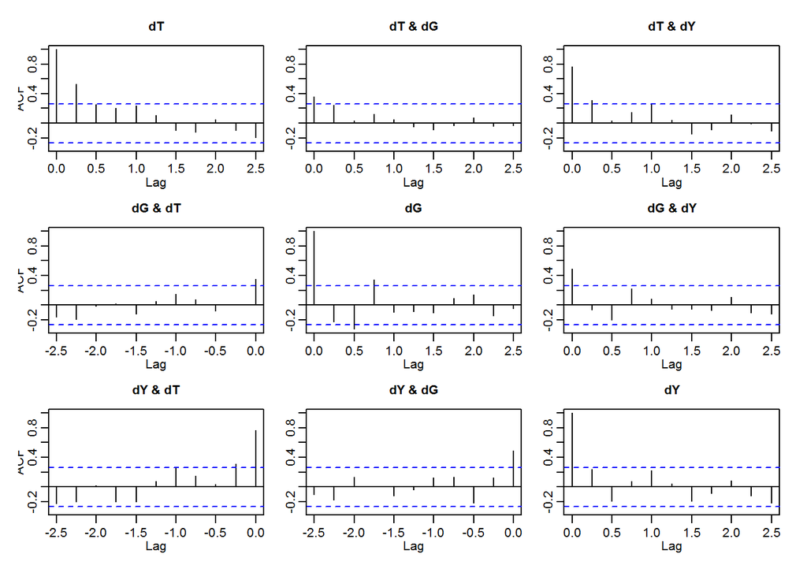

```r
# Diferenciación de las series
dT <- diff(DATOS_VAR[,"T"],lag=1)
dG <- diff(DATOS_VAR[,"G"],lag=1)
dY <- diff(DATOS_VAR[,"Y"],lag=1)

# Funciones de Autocorrelación Simple y Parcial Cruzadas de las variables
acf(cbind(dT,dG,dY), lag.max = 10)
```

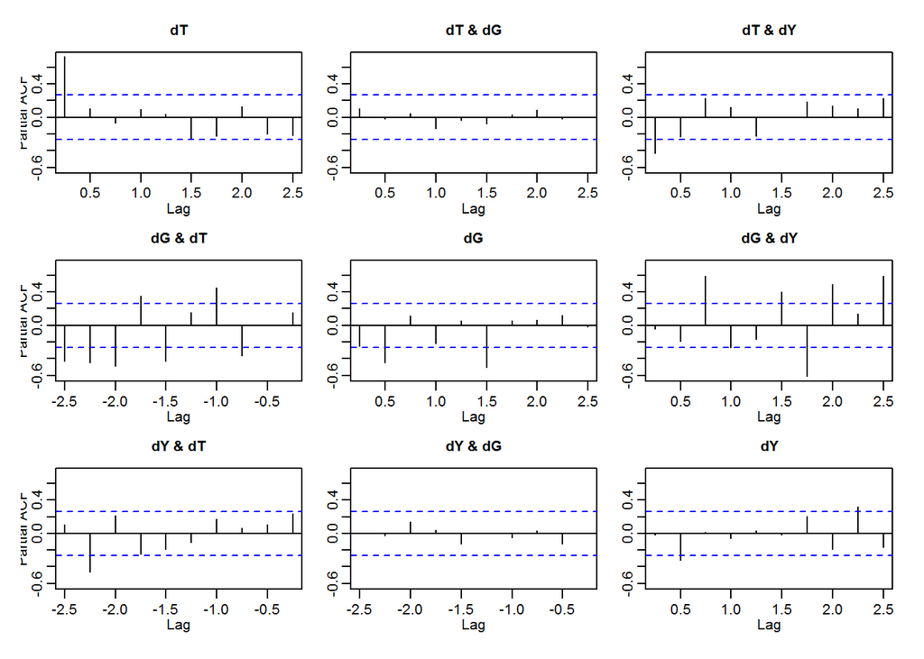

```r
pacf(cbind(dT,dG,dY), lag.max = 10)
```

```r
# Estimación del modelo VAR
varmat <- as.matrix(cbind(dT,dG,dY))
varfit <- VAR(varmat, lag.max = 10, ic="AIC")
summary(varfit)
```

```
##
## VAR Estimation Results:
## =========================
## Endogenous variables: dT, dG, dY
## Deterministic variables: const
## Sample size: 53
## Log Likelihood: 431.013
## Roots of the characteristic polynomial:
## 0.6556 0.6556 0.5874 0.4492 0.4492 0.05605
## Call:
## VAR(y = varmat, lag.max = 10, ic = "AIC")
##
##
## Estimation results for equation dT:
## ===================================
## dT = dT.l1 + dG.l1 + dY.l1 + dT.l2 + dG.l2 + dY.l2 + const
##
##        Estimate Std. Error t value Pr(>|t|)
## dT.l1  0.711276   0.228005   3.120  0.00312 **
## dG.l1  0.084043   0.101053   0.832  0.40989
## dY.l1 -0.379863   0.269165  -1.411  0.16490
## dT.l2  0.106674   0.220884   0.483  0.63143
## dG.l2 -0.016421   0.101496  -0.162  0.87218
## dY.l2 -0.240650   0.276495  -0.870  0.38862
## const  0.004177   0.003045   1.372  0.17675
## ---
## Signif. codes:  0 '***' 0.001 '**' 0.01 '*' 0.05 '.' 0.1 ' ' 1
##
##
## Residual standard error: 0.01995 on 46 degrees of freedom
## Multiple R-Squared: 0.3448,  Adjusted R-squared: 0.2593
## F-statistic: 4.034 on 6 and 46 DF,  p-value: 0.002499
##
##
## Estimation results for equation dG:
## ===================================
## dG = dT.l1 + dG.l1 + dY.l1 + dT.l2 + dG.l2 + dY.l2 + const
##
##        Estimate Std. Error t value Pr(>|t|)
## dT.l1  0.540938   0.343517   1.575  0.12218
```

[output cut: 33 more lines]

```
## F-statistic: 2.656 on 6 and 46 DF,  p-value: 0.02691
##
##
##
## Covariance matrix of residuals:
##           dT        dG        dY
## dT 0.0003979 0.0002959 0.0002574
## dG 0.0002959 0.0009032 0.0002139
## dY 0.0002574 0.0002139 0.0002648
##
## Correlation matrix of residuals:
##        dT     dG     dY
## dT 1.0000 0.4936 0.7930
## dG 0.4936 1.0000 0.4374
## dY 0.7930 0.4374 1.0000
```

## 6. ANÁLISIS DE RESIDUALES DEL MODELO VAR

Con el fin de verificar si el modelo VAR está correctamente especificado, se procede a realizar los test de normalidad multivariada (Jarque-Bera multivariada) y de independencia o ausencia de autocorrelación en los residuos multivariado (Ljung-Box multivariada), para los cuales se espera no rechazar la $H_{0}$ de cada uno de los test. Específicamente, las pruebas de hipótesis a evaluar son:

```r
# Test autocorrelación multivariada
serial.test(varfit, lags.pt = 20, type = "PT.asymptotic")
```

```
##
##  Portmanteau Test (asymptotic)
##
## data:  Residuals of VAR object varfit
## Chi-squared = 120.49, df = 162, p-value = 0.9938
```

```r
# Test de Normalidad multivariada
normality.test(varfit, multivariate.only = T)
```

```
## $JB
##
##  JB-Test (multivariate)
##
## data:  Residuals of VAR object varfit
## Chi-squared = 61.896, df = 6, p-value = 1.852e-11
##
##
## $Skewness
##
##  Skewness only (multivariate)
##
## data:  Residuals of VAR object varfit
## Chi-squared = 13.364, df = 3, p-value = 0.003912
##
##
## $Kurtosis
##
##  Kurtosis only (multivariate)
##
## data:  Residuals of VAR object varfit
## Chi-squared = 48.532, df = 3, p-value = 1.641e-10
```

## 7. FUNCIONES DE IMPULSO RESPUESTA

Con el fin de mostrar las funciones de Impulso Respuesta, se determinó dejar como primera ecuación la variable de lOS Impuestos (T), puesto que siguiendo a Blanchard y Perotti (2002), es la variable más exógena; seguido por la variable de Gasto del Gobierno (G) y por último la variable del PIB.

Los resultados, de las funciones impulso respuesta ortogonalizadas utilizando la descomposición de Cholesky, muestran los siguientes resultados:

- Para el caso de un choque en la tasa de crecimiento de los Impuestos (T), el efecto desaparece a partir del tercer trimestre; sin embargo, para el efecto sobre las tasas de crecimiento sobre el Gasto del Gobierno (G) y el PIB (Y) solo dura 2 trimestres seguidos.
- Para un choque de la variable en la tasa de crecimiento del Gasto del Gobierno (G) perdura hasta 5 trimestres adelante; mientras que no muestra efecto sobre la tasa de crecimiento de los Impuestos y del Producto (Y).
- Para un choque en la variable de la tasa de crecimiento del PIB (Y) se normaliza a partir del 4 trimestre; mientras que el efecto sobre la tasa de crecimietno de los Impuestos (T) y el Gasto del Gobierno (G) resulta ser de una magnitud baja y negativo, además, que se diluye a partir del 4 trimestre.

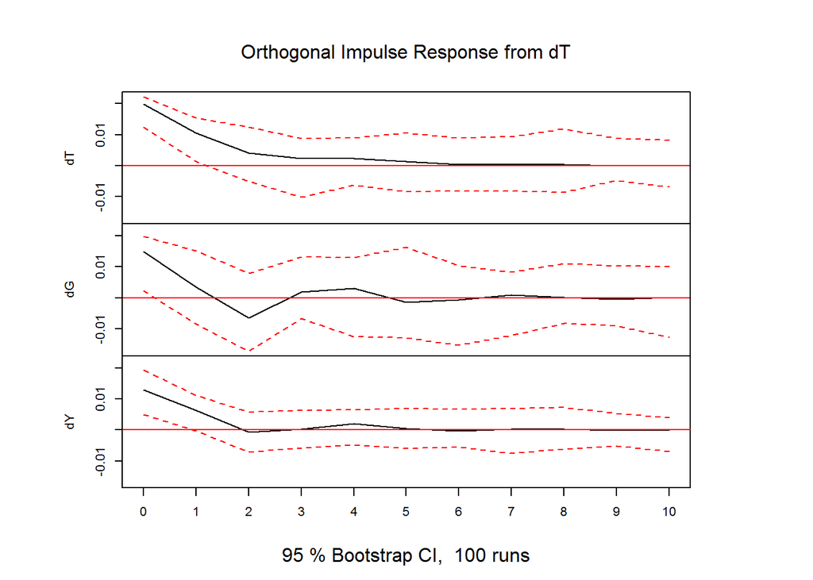

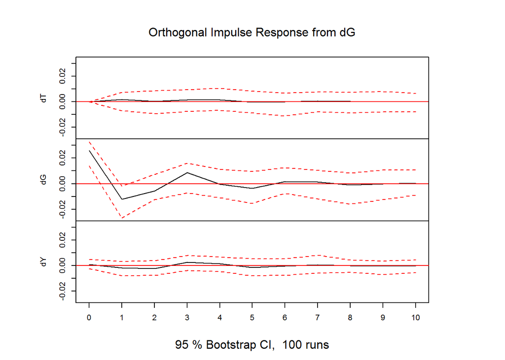

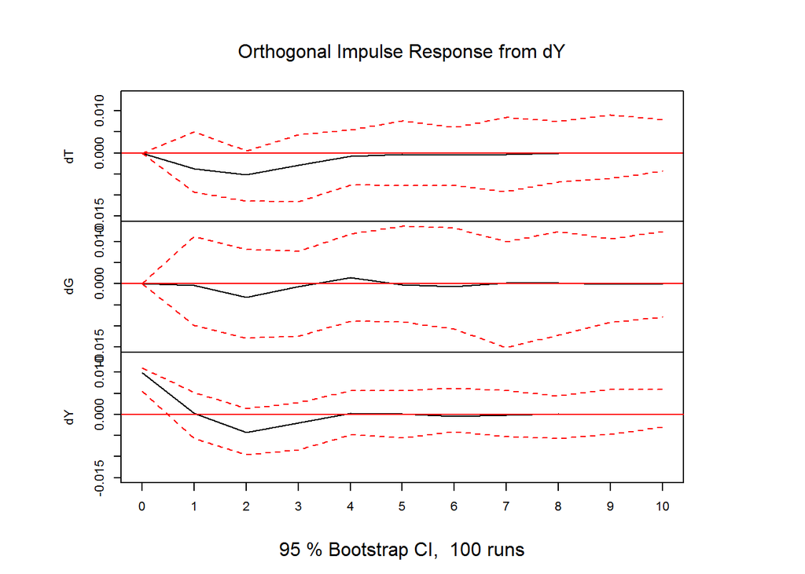

```r
plot(irf(varfit))
```

## 8. DESCOMPOSIÓN DE VARIANZA DEL ERROR DE PREDICCIÓN

De acuerdo con los resultados obtenidos de la Función de Impulso Respuesta, se obtiene la *Descomposición de Varianzas del Error de Predicción*, la cual permite dividir la varianza del error de predicción de cada variable en los componentes que son atribuibles a los distintos choques (*innovaciones*) que experimenta el sistema de ecuaciones del VAR. Con esto, permite identificar cuanto porcentaje del comportamiento futuro de una variable es atribuido a las otras variables del modelo.

De acuerdo con los siguientes resultados se puede concluir que:

- La Descomposición de Varianza para la tasa de crecimiento de los Impuestos (T) no se evidencia una dependencia lo suficientemente relevante de las innovaciones o choques de las tasas de crecimiento del Gasto del Gobierno (G) y del PIB (Y); puesto que, la varianza atribuida a los Impuestos (T) es explicada practicamente en su totalidad por ella misma (aproximadamente el 90%); mientras que el PIB (Y) solo contribuye con aproximadamente el 8% y el Gasto del Gobierno 2%.
- La Descomposición de Varianza para la tasa de crecimiento del Gasto del Gobierno (G) se evidencia una dependencia relevante de las innovaciones o choques de las tasas de crecimiento de los Impuestos (T), pero no con el PIB (Y); puesto que, la varianza atribuida al Gasto del Gobierno (G) es explicada por alrededor de un 76% por la misma variable y un aproximado del 23% de los Impuestos (T); mientras que el PIB (Y) solo contribuye con aproximadamente el 1% de la varianza total.
- La Descomposición de Varianza para la tasa de crecimiento del PIB (Y) se evidencia una dependencia fuerte de las innovaciones o choques de las tasas de crecimiento de los Impuestos (T), pero no con el Gasto del Gobierno (G); puesto que, la varianza atribuida al PIB (Y) es explicada por alrededor de un 60% por los Impuestos (T) y un aproximado del 34% es explicado por la misma variable; mientras que el Gasto del Gobierno (G) solo contribuye con aproximadamente el 5% de la varianza total.

```r
fevd(varfit)
```

```
## $dT
##              dT          dG         dY
##  [1,] 1.0000000 0.000000000 0.00000000
##  [2,] 0.9666129 0.006644442 0.02674264
##  [3,] 0.9216350 0.006332670 0.07203235
##  [4,] 0.9065319 0.009713025 0.08375511
##  [5,] 0.9034701 0.012954741 0.08357517
##  [6,] 0.9034976 0.012991963 0.08351045
##  [7,] 0.9030749 0.013034333 0.08389078
##  [8,] 0.9026730 0.013310598 0.08401636
##  [9,] 0.9026582 0.013332594 0.08400921
## [10,] 0.9026348 0.013353707 0.08401145
##
## $dG
##              dT        dG           dY
```

[output cut: 23 more lines]

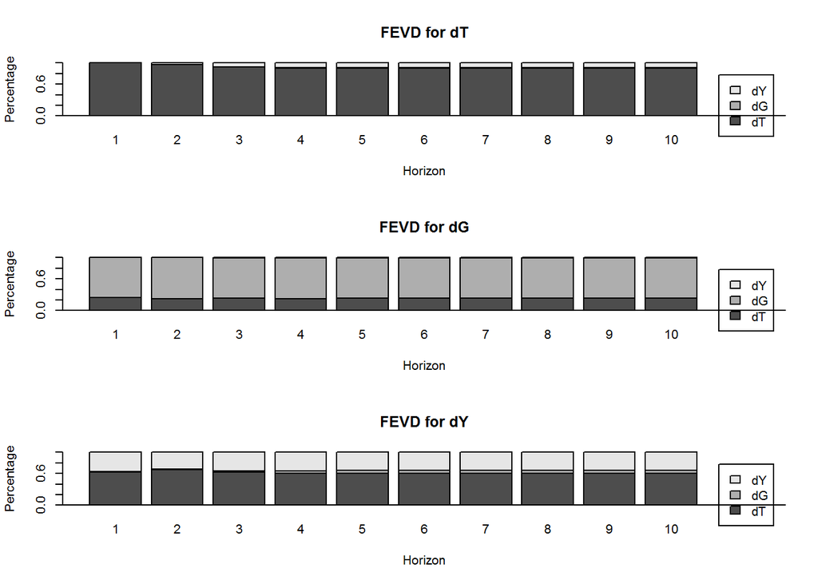

```r
plot(fevd(varfit))
```

## 9. CAUSLIDAD DE GRANGER Y CAUSALIDAD INSTANTÁNEA

Para probar si una variable dentro del sistema de ecuaciones del VAR precede a las demás, se realiza una prueba de Causalidad de Granger con la cual se busca contrastar si una de las variables es estricta exogena con respecto a las demás, versus lo contrario. Por otro lado, tambien se puede evaluar si una variable causa instantáneamente a las demás con el fin de verificar si los choques o innovaciones de la variable bajo análisis afectan contemporáneamente a las demás variables del sistema VAR. En este sentido, se buscan contrastar las siguientes pruebas de hipótesis:

- **Test de Causalidad de Granger:**
  - $H_{0}:$ Estricta Exogeneidad - La variable de evaluación es independiente de las demás
  - $H_{1}:$ No Estricta Exogeneidad - La variable de evaluación no es independiente de las demás
- **Test de Causalidad Instantánea:**
  - $H_{0}:$ No Causalidad Instantánea
  - $H_{1}:$ Causalidad Instantánea

De acuerdo con los resultados de los Test se concluye lo siguiente:

- La tasa de crecimiento de los Impuestos (T) no precede (no causa en sentido Granger) a las tasas de crecimiento del Gasto del Gobierno (G) y el PIB (Y); sin embargo, si las causa de manera instantánea; es decir, los choques de la variable afectarían contemporáneamente a las demás.
- La tasa de crecimiento del Gasto de Gobierno (G) precede (causa en sentido Granger) a las tasas de crecimiento del Gasto del Gobierno (G) y el PIB (Y); sin embargo, también las causa de manera instantánea; es decir, los choques del Gasto del Gobierno afectan tanto el PIB (Y) como los Impuestos (Y) contemporáneamente como en los siguientes periodos.
- La tasa de crecimiento del PIB (Y) no precede (no causa en sentido Granger) a las tasas de crecimiento del Gasto del Gobierno (G) y de los Impuestos (T); sin embargo, si las causa de manera instantánea; es decir, los choques de la variable afectarían contemporáneamente a las demás.

```r
causality(varfit, cause = "dT")
```

```
## $Granger
##
##  Granger causality H0: dT do not Granger-cause dG dY
##
## data:  VAR object varfit
## F-Test = 1.7682, df1 = 4, df2 = 138, p-value = 0.1387
##
##
## $Instant
##
##  H0: No instantaneous causality between: dT and dG dY
##
## data:  VAR object varfit
## Chi-squared = 20.986, df = 2, p-value = 2.774e-05
```

```r
causality(varfit, cause = "dG")
```

```
## $Granger
##
##  Granger causality H0: dG do not Granger-cause dT dY
##
## data:  VAR object varfit
## F-Test = 2.4733, df1 = 4, df2 = 138, p-value = 0.04727
##
##
## $Instant
##
##  H0: No instantaneous causality between: dG and dT dY
##
## data:  VAR object varfit
## Chi-squared = 10.577, df = 2, p-value = 0.005048
```

```r
causality(varfit, cause = "dY")
```

```
## $Granger
##
##  Granger causality H0: dY do not Granger-cause dT dG
##
## data:  VAR object varfit
## F-Test = 1.0212, df1 = 4, df2 = 138, p-value = 0.3987
##
##
## $Instant
##
##  H0: No instantaneous causality between: dY and dT dG
##
## data:  VAR object varfit
## Chi-squared = 20.518, df = 2, p-value = 3.505e-05
```

## 10. BIBLIOGRAFÍA

- Blanchard, Olivier and Robert Perotti. (2002) “An Empirical Characterization Of The Dynamic Effects Of Changes In Government Spending And Taxes On Output,” Quarterly Journal of Economics, v107, 1329-1368.